# Bagging, Random forests, Boosting

Reto Wüest

3/26/2018

## Bagging

Here we apply bagging to the 2005 BES survey data, using the `randomForest` package in `R`. Recall that bagging is a special case of a random forest with $m = p$. Therefore, the `randomForest()` function can be used to perform both random forests and bagging. We perform bagging as follows:

```r
library(randomForest)

# Load data set
load("bes_2005.RData")

# Create training and test sets
set.seed(1234)
train <- sample(1:nrow(bes_2005), size = as.integer(nrow(bes_2005) / 2))
bes_2005_test <- bes_2005[-train, ]
vote_2005_test <- bes_2005$vote_2005[-train]

# Bagging
set.seed(1234)
bag_1 <- randomForest(household_income ~ ., data = bes_2005, subset = train,
                      mtry = 7, importance = TRUE)
bag_1
```

```
##
## Call:
##  randomForest(formula = household_income ~ ., data = bes_2005,      mtry = 7, importance = TRUE, subset = train)
##                Type of random forest: regression
##                      Number of trees: 500
## No. of variables tried at each split: 7
##
##           Mean of squared residuals: 8.813623
##                     % Var explained: 14.23
```

Note that the argument `mtry = 7` indicates that all 7 predictors should be considered for each split of the tree—in other words, that bagging should be done. How well does this bagged model perform on the test set?

```r
# Predict outcomes
bag_1_pred <- predict(bag_1, newdata = bes_2005_test)

# MSE
household_income_test <- bes_2005$household_income[-train]
mean((bag_1_pred - household_income_test)^2)
```

```
## [1] 11.3849
```

Growing a random forest proceeds in exactly the same way, except that we use a smaller value of the `mtry` argument. By default, `randomForest()` uses $p/3$ variables when building a random forest of regression trees, and $\sqrt{p}$ variables when building a random forest of classification trees. Here we use `mtry = 3`.

```r
# Random forest
set.seed(1234)
rf_1 <- randomForest(household_income ~ ., data = bes_2005, subset = train,
                     mtry = 3, importance = TRUE)

# Predict outcomes
rf_1_pred <- predict(rf_1, newdata = bes_2005_test)

# MSE
mean((rf_1_pred - household_income_test)^2)
```

```
## [1] 10.49424
```

The test set MSE is 10.49. This indicates that random forests yielded an improvement over bagging in this case. Using the `importance()` and `varImpPlot()` functions, we can view the importance of each variable.

```r
# Variable importance
importance(rf_1)
```

```
##             %IncMSE IncNodePurity
## vote_2005 11.665744      157.8210
## vote_2001 23.246025      186.5598
## female     5.225216      162.7271
## party_id  16.091845      190.4920
## phone     22.284473      125.1718
## education 66.508981     1164.5620
## duty      13.134319      375.1277
```

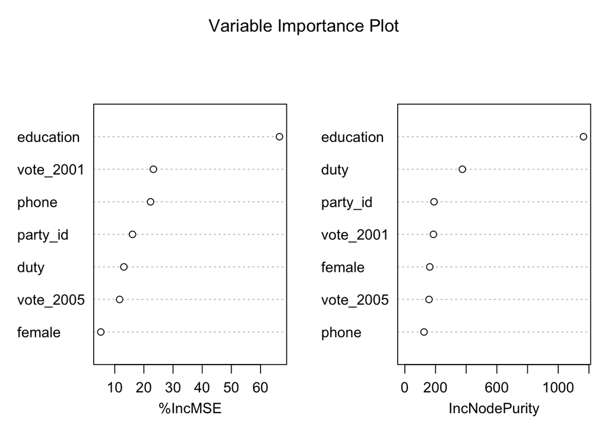

```r
# Variable importance plot
varImpPlot(rf_1, main = "Variable Importance Plot")
```

## Boosting

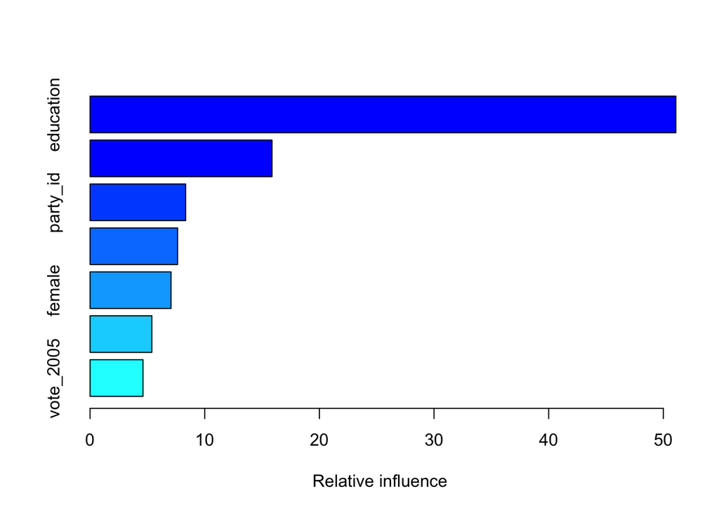

```
##                 var   rel.inf
## education education 51.094136
## duty           duty 15.868715
## party_id   party_id  8.338671
## vote_2001 vote_2001  7.632323
## female       female  7.059228
## phone         phone  5.389219
## vote_2005 vote_2005  4.617708
```

```r
library(gbm)

# Boosting
set.seed(1234)

boost_1 <- gbm(household_income ~ ., data = bes_2005[train, ],
               distribution = "gaussian",
               n.trees = 5000,
               interaction.depth = 4,
               shrinkage = 0.001)

summary(boost_1)
```

We now use the boosted model to predict household income on the test set:

```r
# Predict outcomes
boost_1_pred <- predict(boost_1, newdata = bes_2005_test, n.trees = 5000)

# MSE
mean((boost_1_pred - household_income_test)^2)
```

```
## [1] 9.837483
```

The test MSE obtained is 9.84; superior to both the test MSE for random forests and that for bagging.